# Lab5

Molly Carrick

11/8/2020

```r
library(tidyverse)
```

```r
library(maps)
library(mapproj)
library(ggplot2)

acc <- read.csv("https://raw.githubusercontent.com/xdaiISU/ds202materials/master/hwlabs/fars2017/accident.csv", stringsAsFactors = FALSE)

per<- read.csv("https://raw.githubusercontent.com/xdaiISU/ds202materials/master/hwlabs/fars2017/person.csv", stringsAsFactors = FALSE)
```

1)Are there some days of the week where more accidents happen than the others (see FARS manual, use variable DAY_WEEK)?

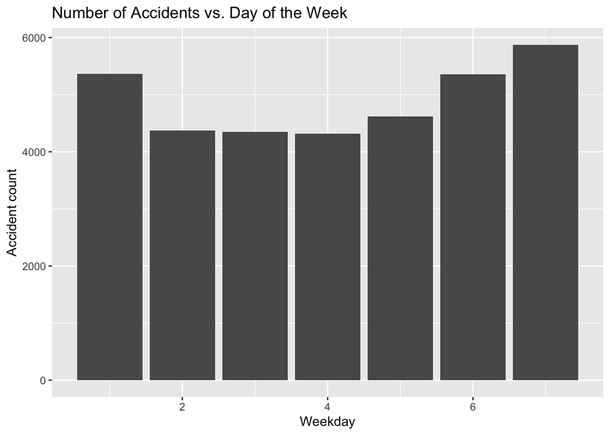

```r
accDay<-acc %>%
  group_by(DAY_WEEK)

ggplot(data=accDay,aes(x=DAY_WEEK))+geom_bar()+ggtitle('Number of Accidents vs. Day of the Week')+xlab('Weekday')+ylab('Accident count')
```

According to this bar chart, it appears that the most accidents happen on weekends. Monday, Tuesday, and Wednesday all practically share the same number of accidents. The number increases on Thursday and continues to increase until is peaks on Saturday. There are a lot of accidents on Sunday as well. The reason for this trend is probably that people party more on weekends and so they get into more accidents since they are not of sound mind.

Create a data frame containing the persons who are fatally hurt in the accidents (look up variable INJ_SEV) (Fatal Injury is a 4)

```r
fatality<-per%>%
  filter(INJ_SEV==4)

head(fatality)
```

```
##   STATE ST_CASE VE_FORMS VEH_NO PER_NO STR_VEH COUNTY DAY MONTH HOUR MINUTE
## 1     1   10001        1      1      1       0     73  19     2   23     35
## 2     1   10002        1      1      1       0     89  14     2   14     59
## 3     1   10003        3      2      1       0    101  31     1   20     31
## 4     1   10004        1      1      1       0     73   1     1   16     55
## 5     1   10005        1      1      1       0     13   1     1   20      0
## 6     1   10006        2      1      1       0     49   6     1   18     40
##   RUR_URB FUNC_SYS HARM_EV MAN_COLL SCH_BUS MAKE MAK_MOD BODY_TYP MOD_YEAR
## 1       2        1      38        0       0   20   20421       15     2004
## 2       2        1       1        0       0   37   37402       14     2005
## 3       2        1      12        1       0    2    2404       14     2003
## 4       2        4      30        0       0   30   30046        4     2014
## 5       1        1      35        0       0   12   12471       34     2010
## 6       1        1      34        0       0   49   49032        4     1997
##   TOW_VEH SPEC_USE EMER_USE ROLLOVER IMPACT1 FIRE_EXP AGE SEX PER_TYP INJ_SEV
```

[output cut: 41 more lines]

Create a data frame containing the most dangerous vehicle make in each state. The number of persons fatally hit in the vehicle make is used to assess the (non-)safety of a make. Make sure to handle the missing values appropriately. (look up variable MAKE)

```r
dangerous<-fatality%>%
  group_by(STATE,MAKE)%>%
  summarize(n=n())%>%
  group_by(STATE)%>%
  filter(n==max(n))


head(dangerous)
```

```
## # A tibble: 6 x 3
## # Groups:   STATE [6]
##   STATE  MAKE     n
##   <int> <int> <int>
## 1     1    12   138
## 2     2    NA    17
## 3     4    NA   261
## 4     5    20    88
## 5     6    NA  1012
## 6     8    NA   108
```

4)Create a map, and label each state with the most dangerous vehicle. Discuss the definition of the most dangerous vehicle, and what you find from the map. (Hint: Read the description for the STATE and COUNTY columns in the FARS manual. The state & county codes are Geographic Locator Codes (GLCs) from the General Services Administration’s (GSA) publication. Use readxl::read_xlsx to read in the GLCs.)

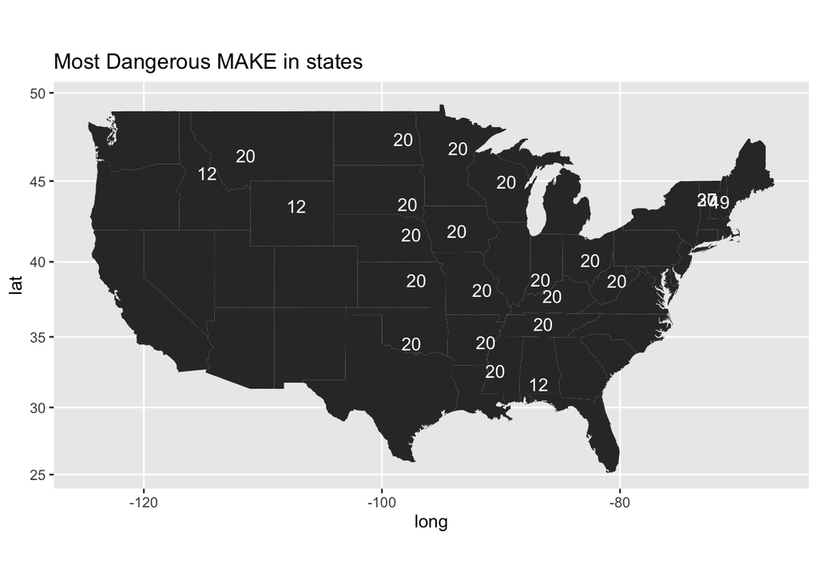

```r
state<-map_data("state")
GLC<-readxl::read_xlsx("FRPP_GLC_-_United_StatesSep292020.xlsx")
statesName<-state%>%
  group_by(region)%>%
  summarize(long=mean(long),lat=mean(lat))

statesCode<-GLC%>%
  select(c(`State Name`, `State Code`))%>%
  group_by(`State Name`)%>%
  summarize(STATE=max(`State Code`))%>%
  mutate(STATE=as.numeric(STATE))

statesCode$`State Name`<-tolower(statesCode$`State Name`)

combine<-statesCode%>%
  left_join(dangerous)
formattedCombine<-combine%>%
  select(c(`State Name`, MAKE))%>%
  rename(region=`State Name`)

newStatesName<-statesName%>%
  left_join(formattedCombine)
state%>%
  ggplot(aes(x=long, y=lat))+
  geom_polygon(aes(group=group))+
  geom_text(aes(label=MAKE),color='white', data=newStatesName)+
  ggtitle('Most Dangerous MAKE in states')+
  coord_map()
```

5)Join the accident and person table (work out which variable(s) to use)

```r
together<-acc%>%
  left_join(per)
```

6)Tally the number of accidents by day of the week (DAY_WEEK), hour of the day (HOUR) and gender (SEX). Visualize the results.

```r
table(together$DAY_WEEK)
```

```
##
##     1     2     3     4     5     6     7
## 13360 10671 10571 10464 11311 13634 14910
```

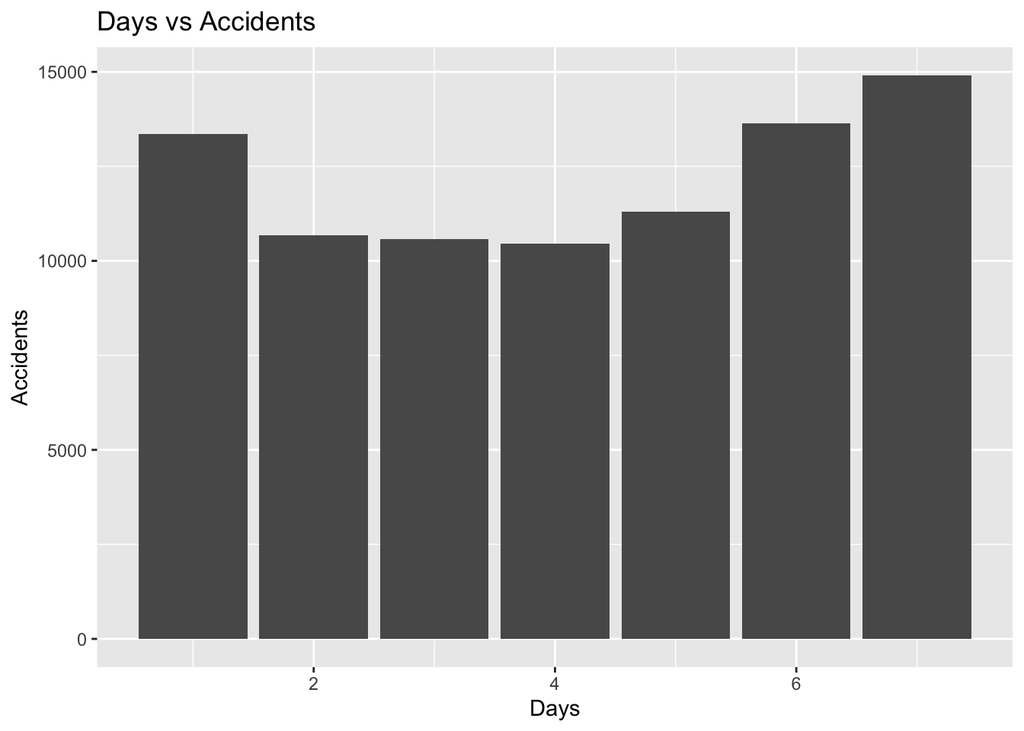

```r
day<-together%>%
  group_by(DAY_WEEK)

ggplot(data=day,aes(x=DAY_WEEK))+geom_bar()+ggtitle('Days vs Accidents')+xlab('Days')+ylab('Accidents')
```

```r
table(together$HOUR)
```

```
##
##    0    1    2    3    4    5    6    7    8    9   10   11   12   13   14   15
## 2928 2540 2735 2096 1706 2269 2880 2824 2183 2301 2719 2952 3716 3888 4223 4839
##   16   17   18   19   20   21   22   23   99
## 4828 5268 5409 4748 4967 4802 4114 3578  408
```

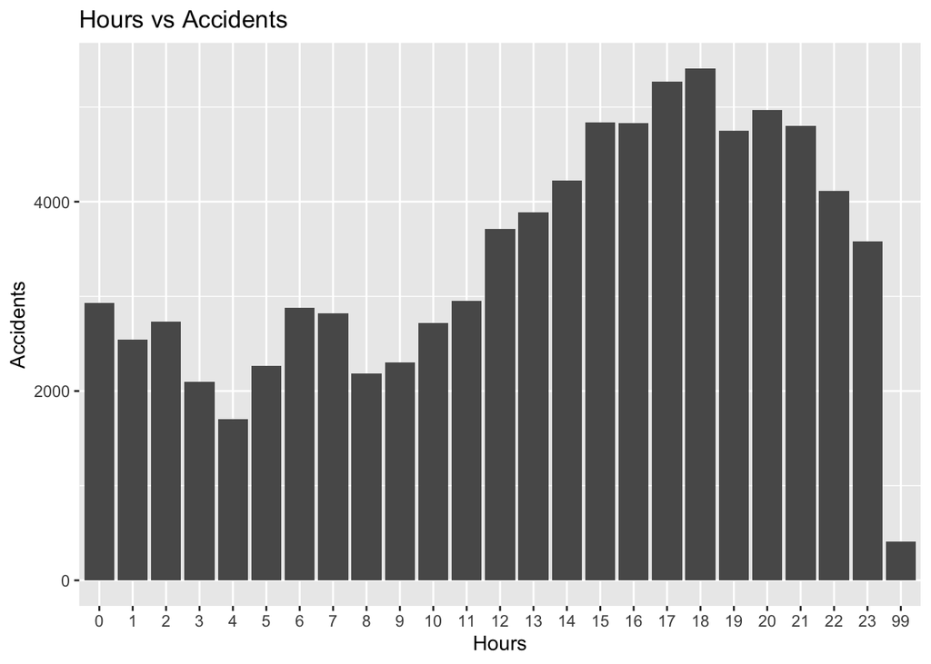

```r
hour<-together%>%
  group_by(HOUR)

hour$HOUR<-factor(hour$HOUR)

ggplot(data=hour, aes(x=HOUR))+geom_bar()+ggtitle('Hours vs Accidents')+xlab('Hours')+ylab('Accidents')
```

```r
table(together$SEX)
```

```
##
##     1     2     8     9
## 55230 28149   473  1069
```

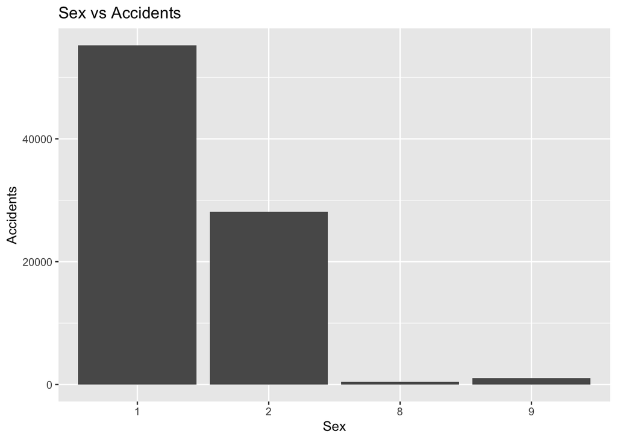

```r
sex<-together%>%
  group_by(SEX)

sex$SEX<-factor(sex$SEX)

ggplot(data=sex, aes(x=SEX))+geom_bar()+ggtitle('Sex vs Accidents')+xlab('Sex')+ylab('Accidents')
```

7)Now plot a choropleth map of the number of deaths on a county level.

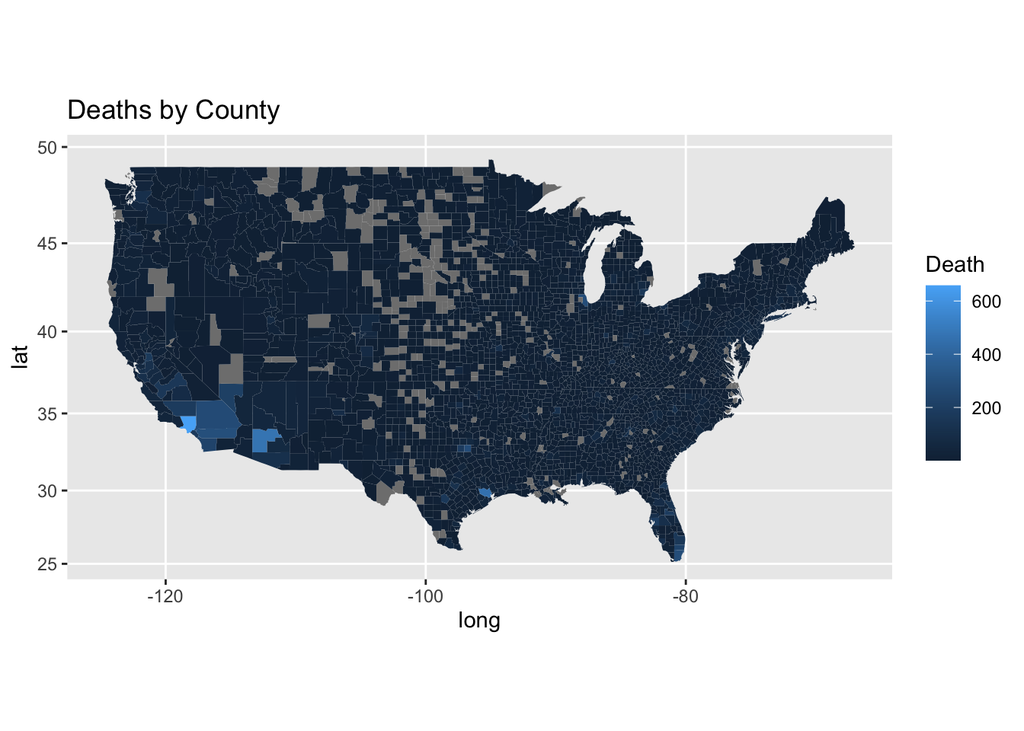

```r
county<-map_data("county")

deaths<-fatality%>%
  group_by(STATE,COUNTY)%>%
  summarize(Death=n())


countyCode<-GLC%>%
  select(c(`State Name`, `State Code`, `County Code`,`County Name`))%>%
  group_by(`State Name`,`County Name`)%>%
  summarize(STATE=max(`State Code`), COUNTY=max(`County Code`))%>%
  mutate(STATE=as.numeric(STATE), COUNTY=as.numeric(COUNTY))

countyCode$`State Name`<-tolower(countyCode$`State Name`)
countyCode$`County Name`<-tolower(countyCode$`County Name`)


countyJoin<-deaths%>%
  left_join(countyCode)
countyNames<-county%>%
  group_by(region,subregion)%>%
  summarize(long=mean(long),lat=mean(lat))

formattedCountyJoin<-countyJoin%>%
  rename(region=`State Name`, subregion=`County Name`)

newCountyNames<-formattedCountyJoin%>%
  left_join(countyNames)
graph<-newCountyNames%>%
   select(region,subregion,Death)
 newGraph<-county%>%
   left_join(graph)
  ggplot(newGraph, aes(x=long, y=lat, fill=Death)) +
  geom_polygon(aes(group=group))+
  coord_map()+
  ggtitle('Deaths by County')
```

8)Is summer or winter more dangerous? Does this depend on states? Explore and explain.

```r
mon<-per%>%
  group_by(STATE,MONTH)%>%
  summarize(n=n())

win<-mon%>%
  filter(MONTH%in%c(12,1,2,3))

sum<-mon%>%
  filter(MONTH%in%c(6,7,8,9))


winTotal<-win%>%
  ungroup()%>%
  summarize(total=sum(n))

sumTotal<-sum%>%
  ungroup()%>%
  summarize(total=sum(n))

winTotal
```

```
## # A tibble: 1 x 1
##   total
##   <int>
## 1 25963
```

```r
sumTotal
```

```
## # A tibble: 1 x 1
##   total
##   <int>
## 1 30472
```

Without taking the indiviual states into account, it appears that the summer months are more dangerous. There are a total of 30,472 accidents recorded in the summer and 25,963 accidents recorded in the winter.

```r
winS<-win%>%
  group_by(STATE)%>%
  summarize(num=sum(n))

sumS<-sum%>%
  group_by(STATE)%>%
  summarize(num=sum(n))


winterState<-winS%>%
  left_join(statesCode)%>%
  rename(region=`State Name`)
summerState<-sumS%>%
  left_join(statesCode)%>%
  rename(region=`State Name`)
thisWin<-state%>%
  left_join(winterState)
thisSum<-state%>%
  left_join(summerState)
```

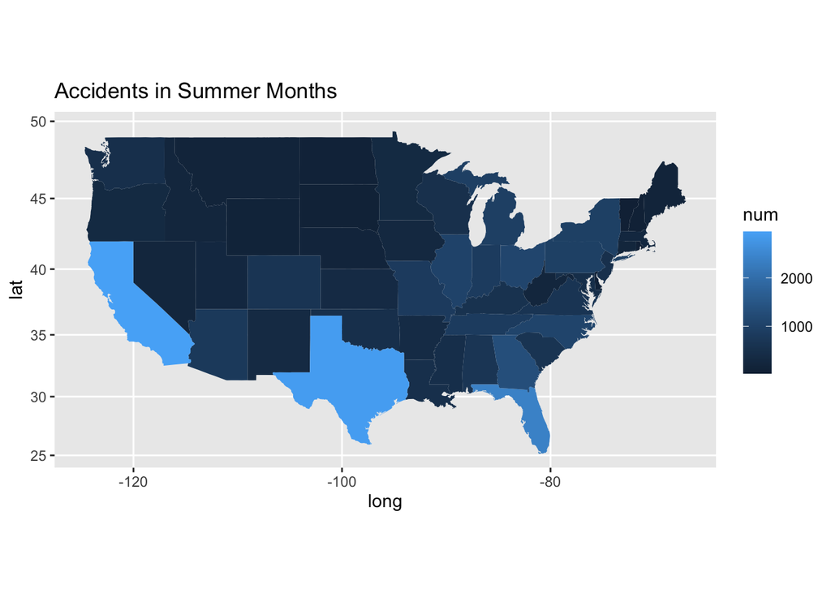

```r
 ggplot(thisSum, aes(x=long, y=lat, fill=num)) +
  geom_polygon(aes(group=group))+
  coord_map()+
   ggtitle('Accidents in Summer Months')
```

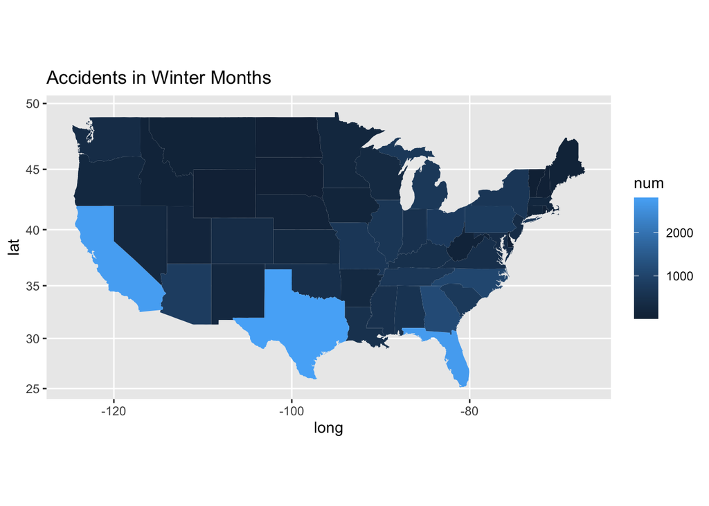

```r
ggplot(thisWin, aes(x=long, y=lat, fill=num)) +
  geom_polygon(aes(group=group))+
  coord_map()+
  ggtitle('Accidents in Winter Months')
```

When taking in states into account, very little is different between the two choropleth maps. It appears that many of the states have more accidents in the summer, which aligns with the number totals we found earlier. However, it is not obvious that a certain state does better/worse whether in the winter or summer. From what I can tell, it does not depend on the states.